# Group Project 2 - Intermediate Deliverable #1

Ethan Peterson, Jose Soria Miquel, Raegan Gothard, Tarini Bengani, and Yashwant Dubbaka

2026-10-22

## Overview of Dataset

We have chosen a patient survival prediction dataset from Kaggle. Each row is an ICU stay, and the binary outcome variable `hospital_death` is whether the patient died during their hospital stay. The dataset has columns regarding the patient’s demographics, how they were admitted to the ICU, vital signs and lab results from their first hour and first 24 hours in the ICU, and chronic conditions.

## Exploratory Data Visualizations

To get a sense of what is related to in-hospital death, we started with a few plots of the raw data.

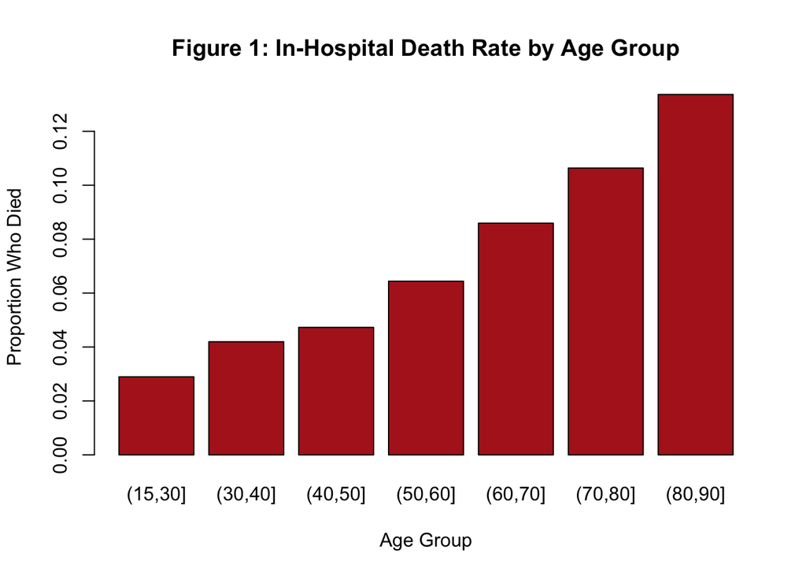

```r
# Load the raw dataset for exploration
raw <- read.csv("patient.csv")

# Figure 1: share of patients who died in each age group
# cut() splits age into 10-year bins, and tapply() takes the mean of hospital_death in each bin
age_group <- cut(raw$age, breaks = c(15, 30, 40, 50, 60, 70, 80, 90))
death_by_age <- tapply(raw$hospital_death, age_group, mean)
barplot(death_by_age,
        col = "firebrick",
        xlab = "Age Group",
        ylab = "Proportion Who Died",
        main = "Figure 1: In-Hospital Death Rate by Age Group")
```

Figure 1 shows the death rate climbing steadily with age, from about 3% for patients 30 and under to about 13% for patients in their 80s.

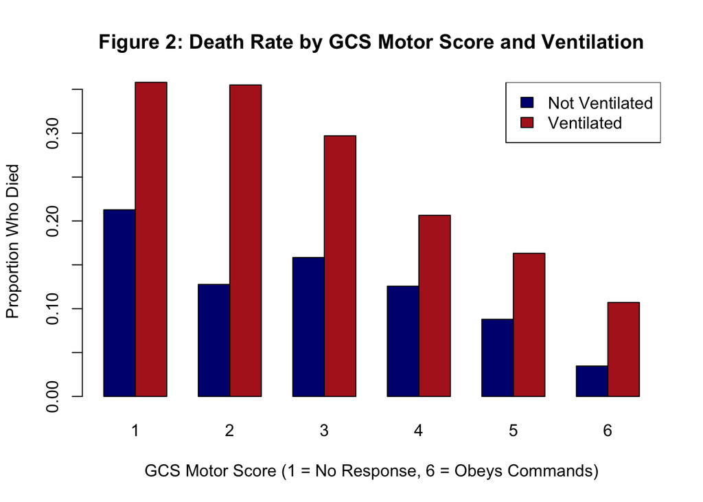

```r
# Figure 2: death rate by GCS motor score, split by whether the patient was ventilated
# GCS motor score runs from 1 (no movement) to 6 (follows commands)
death_by_gcs <- tapply(raw$hospital_death,
                       list(raw$ventilated_apache, raw$gcs_motor_apache), mean)
barplot(death_by_gcs,
        beside = TRUE,                       # draw the two groups side by side
        col = c("navy", "firebrick"),        # 1st = not ventilated, 2nd = ventilated
        xlab = "GCS Motor Score (1 = No Response, 6 = Obeys Commands)",
        ylab = "Proportion Who Died",
        main = "Figure 2: Death Rate by GCS Motor Score and Ventilation")
legend("topright",
       legend = c("Not Ventilated", "Ventilated"),
       fill = c("navy", "firebrick"))
```

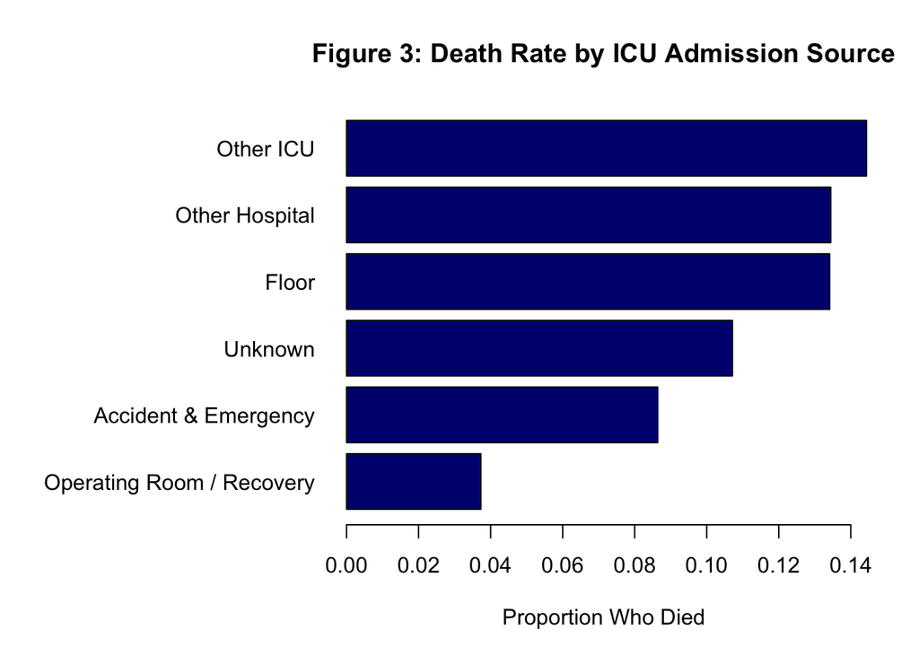

```r
# Figure 3: death rate by where the patient was admitted to the ICU from
src <- raw$icu_admit_source
src[src == ""] <- "Unknown"                  # label blank sources so they show up in the plot
death_by_src <- sort(tapply(raw$hospital_death, src, mean))
par(mar = c(5, 13, 4, 2))                    # widen the left margin so the labels fit
barplot(death_by_src,
        horiz = TRUE, las = 1,               # horizontal bars with readable labels
        col = "navy",
        xlab = "Proportion Who Died",
        main = "Figure 3: Death Rate by ICU Admission Source")
```

```r
par(mar = c(5, 4, 4, 2))                     # reset margins
```

Figure 3 shows that patients coming from the operating room die at only about 4%, likely because many are planned surgeries. Patients transferred from another ICU, another hospital, or a hospital floor die at about 13 to 14%, roughly three times as often.

## Summary Statistics

```r
patient <- read.csv("patient.csv")

str(patient)
```

```
## 'data.frame':    91713 obs. of  85 variables:
##  $ encounter_id                 : int  66154 114252 119783 79267 92056 33181 82208 120995 80471 42871 ...
##  $ patient_id                   : int  25312 59342 50777 46918 34377 74489 49526 50129 10577 90749 ...
##  $ hospital_id                  : int  118 81 118 118 33 83 83 33 118 118 ...
##  $ age                          : int  68 77 25 81 19 67 59 70 45 50 ...
##  $ bmi                          : num  22.7 27.4 31.9 22.6 NA ...
##  $ elective_surgery             : int  0 0 0 1 0 0 0 0 0 0 ...
##  $ ethnicity                    : chr  "Caucasian" "Caucasian" "Caucasian" "Caucasian" ...
##  $ gender                       : chr  "M" "F" "F" "F" ...
##  $ height                       : num  180 160 173 165 188 ...
##  $ icu_admit_source             : chr  "Floor" "Floor" "Accident & Emergency" "Operating Room / Recovery" ...
##  $ icu_id                       : int  92 90 93 92 91 95 95 91 114 114 ...
##  $ icu_stay_type                : chr  "admit" "admit" "admit" "admit" ...
##  $ icu_type                     : chr  "CTICU" "Med-Surg ICU" "Med-Surg ICU" "CTICU" ...
##  $ pre_icu_los_days             : num  0.541667 0.927778 0.000694 0.000694 0.073611 ...
```

[output cut: 71 more lines]

```r
summary(patient)
```

```
##   encounter_id      patient_id      hospital_id         age
##  Min.   :     1   Min.   :     1   Min.   :  2.0   Min.   :16.00
##  1st Qu.: 32852   1st Qu.: 32830   1st Qu.: 47.0   1st Qu.:52.00
##  Median : 65665   Median : 65413   Median :109.0   Median :65.00
##  Mean   : 65606   Mean   : 65537   Mean   :105.7   Mean   :62.31
##  3rd Qu.: 98342   3rd Qu.: 98298   3rd Qu.:161.0   3rd Qu.:75.00
##  Max.   :131051   Max.   :131051   Max.   :204.0   Max.   :89.00
##                                                    NAs    :4228
##       bmi        elective_surgery     ethnicity           gender
##  Min.   :14.84   Min.   :0.0000   Length   :91713   Length   :91713
##  1st Qu.:23.64   1st Qu.:0.0000   N.unique :    7   N.unique :    3
##  Median :27.65   Median :0.0000   N.blank  : 1395   N.blank  :   25
##  Mean   :29.19   Mean   :0.1837   Min.nchar:    0   Min.nchar:    0
##  3rd Qu.:32.93   3rd Qu.:0.0000   Max.nchar:   16   Max.nchar:    1
##  Max.   :67.81   Max.   :1.0000
##  NAs    :3429
##      height       icu_admit_source     icu_id        icu_stay_type
##  Min.   :137.2   Length   :91713   Min.   : 82.0   Length   :91713
##  1st Qu.:162.5   N.unique :    6   1st Qu.:369.0   N.unique :    3
##  Median :170.1   N.blank  :  112   Median :504.0   N.blank  :    0
##  Mean   :169.6   Min.nchar:    0   Mean   :508.4   Min.nchar:    5
##  3rd Qu.:177.8   Max.nchar:   25   3rd Qu.:679.0   Max.nchar:    8
##  Max.   :195.6                     Max.   :927.0
##  NAs    :1334
##       icu_type     pre_icu_los_days        weight       apache_2_diagnosis
##  Length   :91713   Min.   :-24.94722   Min.   : 38.60   Min.   :101.0
##  N.unique :    8   1st Qu.:  0.03542   1st Qu.: 66.80   1st Qu.:113.0
##  N.blank  :    0   Median :  0.13889   Median : 80.30   Median :122.0
##  Min.nchar:    4   Mean   :  0.83577   Mean   : 84.03   Mean   :185.4
##  Max.nchar:   12   3rd Qu.:  0.40903   3rd Qu.: 97.10   3rd Qu.:301.0
##                    Max.   :159.09097   Max.   :186.00   Max.   :308.0
##                                        NAs    :2720     NAs    :1662
##  apache_3j_diagnosis apache_post_operative   arf_apache      gcs_eyes_apache
##  Min.   :   0.01     Min.   :0.0000        Min.   :0.00000   Min.   :1.000
##  1st Qu.: 203.01     1st Qu.:0.0000        1st Qu.:0.00000   1st Qu.:3.000
##  Median : 409.02     Median :0.0000        Median :0.00000   Median :4.000
##  Mean   : 558.22     Mean   :0.2011        Mean   :0.02798   Mean   :3.465
##  3rd Qu.: 703.03     3rd Qu.:0.0000        3rd Qu.:0.00000   3rd Qu.:4.000
##  Max.   :2201.05     Max.   :1.0000        Max.   :1.00000   Max.   :4.000
##  NAs    :1101                              NAs    :715       NAs    :1901
```

[output cut: 129 more lines]

```
##  Min.   :0.00000             Length   :91713      Length   :91713
##  1st Qu.:0.00000             N.unique :   12      N.unique :   11
##  Median :0.00000             N.blank  : 1662      N.blank  : 1662
##  Mean   :0.02064             Min.nchar:    0      Min.nchar:    0
##  3rd Qu.:0.00000             Max.nchar:   20      Max.nchar:   19
##  Max.   :1.00000
##  NAs    :715
##     X           hospital_death
##  Mode:logical   Min.   :0.0000
##  NAs :91713     1st Qu.:0.0000
##                 Median :0.0000
##                 Mean   :0.0863
##                 3rd Qu.:0.0000
##                 Max.   :1.0000
##
```

```r
# How common is the outcome?
table(patient$hospital_death)
```

```
##
##     0     1
## 83798  7915
```

```r
round(prop.table(table(patient$hospital_death)), 3)
```

```
##
##     0     1
## 0.914 0.086
```

```r
# Average of key predictors for patients who survived (0) vs. died (1)
key_vars <- c("age", "bmi", "pre_icu_los_days", "d1_heartrate_max", "d1_sysbp_min",
              "d1_spo2_min", "gcs_motor_apache", "ventilated_apache", "elective_surgery")
round(aggregate(patient[, key_vars], by = list(hospital_death = patient$hospital_death),
                FUN = mean, na.rm = TRUE), 2)
```

```
##   hospital_death   age   bmi pre_icu_los_days d1_heartrate_max d1_sysbp_min
## 1              0 61.75 29.26             0.79           101.90        98.26
## 2              1 68.49 28.34             1.35           114.68        82.77
##   d1_spo2_min gcs_motor_apache ventilated_apache elective_surgery
## 1       91.10             5.58              0.29             0.19
## 2       83.59             4.27              0.67             0.07
```

The data has 91,713 ICU stays and 85 variables. Only 8.6% of patients died in the hospital, so the outcome is imbalanced. A model that predicted “survived” for everyone would already be about 91% accurate, so we look at sensitivity and kappa rather than accuracy when evaluating the model.

The typical patient is 65 years old and reaches the ICU within a few hours of arriving at the hospital. Compared to survivors, patients who died were older (68 vs. 62 on average), had lower minimum blood pressure and oxygen levels on day 1, and were more than twice as likely to be ventilated (67% vs. 29%).

## Data Cleaning

```r
# Remove unique identifier columns and the empty unnamed column
patient$encounter_id <- NULL
patient$patient_id <- NULL
patient$hospital_id <- NULL
patient$icu_id <- NULL
patient$X <- NULL

# The APACHE IV death probabilities are already a prediction of our response variable
patient$apache_4a_hospital_death_prob <- NULL
patient$apache_4a_icu_death_prob <- NULL

# The APACHE diagnosis codes are IDs, not real numbers, and apache_2_bodysystem repeats apache_3j_bodysystem
patient$apache_2_diagnosis <- NULL
patient$apache_3j_diagnosis <- NULL
patient$apache_2_bodysystem <- NULL

# Blank categorical values become their own "Unknown" level, then convert to factors
cat_cols <- names(patient)[sapply(patient, is.character)]
for (v in cat_cols) {
  patient[[v]][patient[[v]] == ""] <- "Unknown"
  patient[[v]] <- as.factor(patient[[v]])
}

# Fill missing numeric values with the column median
colSums(is.na(patient))
```

```
##                         age                         bmi
##                        4228                        3429
##            elective_surgery                   ethnicity
##                           0                           0
##                      gender                      height
##                           0                        1334
##            icu_admit_source               icu_stay_type
##                           0                           0
##                    icu_type            pre_icu_los_days
##                           0                           0
##                      weight       apache_post_operative
##                        2720                           0
##                  arf_apache             gcs_eyes_apache
##                         715                        1901
##            gcs_motor_apache           gcs_unable_apache
##                        1901                        1037
##           gcs_verbal_apache           heart_rate_apache
##                        1901                         878
##            intubated_apache                  map_apache
##                         715                         994
##             resprate_apache                 temp_apache
##                        1234                        4108
##           ventilated_apache               d1_diasbp_max
##                         715                         165
##               d1_diasbp_min   d1_diasbp_noninvasive_max
##                         165                        1040
##   d1_diasbp_noninvasive_min            d1_heartrate_max
##                        1040                         145
##            d1_heartrate_min                  d1_mbp_max
##                         145                         220
##                  d1_mbp_min      d1_mbp_noninvasive_max
##                         220                        1479
##      d1_mbp_noninvasive_min             d1_resprate_max
##                        1479                         385
##             d1_resprate_min                 d1_spo2_max
##                         385                         333
##                 d1_spo2_min                d1_sysbp_max
##                         333                         159
##                d1_sysbp_min    d1_sysbp_noninvasive_max
##                         159                        1027
```

[output cut: 21 more lines]

```
##                        7341                        5807
##              d1_glucose_min            d1_potassium_max
##                        5807                        9585
##            d1_potassium_min                        aids
##                        9585                         715
##                   cirrhosis           diabetes_mellitus
##                         715                         715
##             hepatic_failure           immunosuppression
##                         715                         715
##                    leukemia                    lymphoma
##                         715                         715
## solid_tumor_with_metastasis        apache_3j_bodysystem
##                         715                           0
##              hospital_death
##                           0
```

```r
num_cols <- setdiff(names(patient)[sapply(patient, is.numeric)], "hospital_death")
for (v in num_cols) {
  patient[[v]][is.na(patient[[v]])] <- median(patient[[v]], na.rm = TRUE)
}
sum(is.na(patient))
```

```
## [1] 0
```

```r
# Create dummy variables for categorical data (drop the intercept column so each factor has a reference level)
patient_d <- as.data.frame(model.matrix(~ ., data = patient)[, -1])

str(patient_d)
```

```
## 'data.frame':    91713 obs. of  102 variables:
##  $ age                                      : num  68 77 25 81 19 67 59 70 45 50 ...
##  $ bmi                                      : num  22.7 27.4 31.9 22.6 27.7 ...
##  $ elective_surgery                         : num  0 0 0 1 0 0 0 0 0 0 ...
##  $ ethnicityAsian                           : num  0 0 0 0 0 0 0 0 0 0 ...
##  $ ethnicityCaucasian                       : num  1 1 1 1 1 1 1 1 1 0 ...
##  $ ethnicityHispanic                        : num  0 0 0 0 0 0 0 0 0 0 ...
##  $ ethnicityNative American                 : num  0 0 0 0 0 0 0 0 0 0 ...
##  $ ethnicityOther/Unknown                   : num  0 0 0 0 0 0 0 0 0 0 ...
##  $ ethnicityUnknown                         : num  0 0 0 0 0 0 0 0 0 1 ...
##  $ genderM                                  : num  1 0 0 0 1 1 0 1 1 1 ...
##  $ genderUnknown                            : num  0 0 0 0 0 0 0 0 0 0 ...
##  $ height                                   : num  180 160 173 165 188 ...
##  $ icu_admit_sourceFloor                    : num  1 1 0 0 0 0 0 0 0 0 ...
##  $ icu_admit_sourceOperating Room / Recovery: num  0 0 0 1 0 0 0 0 0 0 ...
```

[output cut: 86 more lines]

## Regression Model

### Splitting the Data

We split the data into a 70% training set and a 30% test set, so the model is judged on patients it has never seen.

```r
ratio <- 0.7
set.seed(12345)
train_rows <- sample(1:nrow(patient_d), ratio*nrow(patient_d))

patient_train <- patient_d[train_rows, ]
patient_test <- patient_d[-train_rows, ]

# The death rate should be similar in both sets if the split is fair
mean(patient_train$hospital_death); mean(patient_test$hospital_death)
```

```
## [1] 0.08588919
```

```
## [1] 0.08726467
```

The death rate is about 8.6% in the training set and 8.7% in the test set, so the split is representative.

### Logistic Regression

Logistic regression is used when the outcome is binary, like died or survived. Instead of predicting a number directly, it estimates the probability that each patient falls in the “1” group, using a curve that always stays between 0 and 1. Each coefficient shows how a variable shifts the odds of the outcome while holding the others constant.

This lines up directly with our business question. The coefficients answer the first part, which characteristics predict in-hospital death (the why), and the predicted probabilities answer the second, since a hospital could flag patients above a chosen risk level in their first 24 hours and give them priority for ICU staff, monitoring and beds.

```r
logmodel <- glm(hospital_death ~ ., data = patient_train, family = "binomial")

summary(logmodel)
```

```
##
## Call:
## glm(formula = hospital_death ~ ., family = "binomial", data = patient_train)
##
## Coefficients:
##                                               Estimate Std. Error z value
## (Intercept)                                  1.721e+01  1.349e+00  12.757
## age                                          2.865e-02  1.281e-03  22.357
## bmi                                          2.851e-03  8.766e-03   0.325
## elective_surgery                            -8.673e-01  1.109e-01  -7.817
## ethnicityAsian                               5.787e-02  1.624e-01   0.356
## ethnicityCaucasian                           9.683e-02  5.996e-02   1.615
## ethnicityHispanic                            2.361e-01  9.787e-02   2.412
## `ethnicityNative American`                   3.052e-01  1.753e-01   1.741
## `ethnicityOther/Unknown`                     1.140e-01  9.725e-02   1.173
## ethnicityUnknown                             3.022e-01  1.544e-01   1.958
## genderM                                      7.360e-02  4.584e-02   1.606
## genderUnknown                                8.224e-01  9.025e-01   0.911
## height                                       1.714e-03  3.817e-03   0.449
## icu_admit_sourceFloor                        1.784e-01  4.371e-02   4.081
## `icu_admit_sourceOperating Room / Recovery` -6.722e-01  1.190e-01  -5.651
## `icu_admit_sourceOther Hospital`             3.415e-01  9.072e-02   3.764
## `icu_admit_sourceOther ICU`                  6.087e-01  1.380e-01   4.412
## icu_admit_sourceUnknown                      1.406e-01  4.554e-01   0.309
## icu_stay_typereadmit                        -2.028e-01  2.021e-01  -1.004
## icu_stay_typetransfer                       -2.823e-01  7.032e-02  -4.014
## `icu_typeCCU-CTICU`                         -1.042e-01  9.248e-02  -1.127
## icu_typeCSICU                               -5.230e-01  1.149e-01  -4.550
## icu_typeCTICU                               -2.747e-01  1.182e-01  -2.323
## `icu_typeMed-Surg ICU`                      -1.986e-01  7.292e-02  -2.723
## icu_typeMICU                                -9.253e-02  8.539e-02  -1.084
## `icu_typeNeuro ICU`                          2.862e-02  9.582e-02   0.299
## icu_typeSICU                                -1.821e-02  9.968e-02  -0.183
## pre_icu_los_days                             4.287e-02  5.334e-03   8.038
## weight                                      -4.374e-03  3.151e-03  -1.388
## apache_post_operative                        2.818e-01  1.340e-01   2.102
## arf_apache                                   3.052e-01  8.838e-02   3.453
## gcs_eyes_apache                             -1.313e-01  2.843e-02  -4.619
## gcs_motor_apache                            -2.056e-01  1.644e-02 -12.507
## gcs_unable_apache                            1.021e+00  1.196e-01   8.532
```

[output cut: 166 more lines]

```
## apache_3j_bodysystemNeurological            5.70e-06 ***
## apache_3j_bodysystemRespiratory             0.603061
## apache_3j_bodysystemSepsis                  0.009717 **
## apache_3j_bodysystemTrauma                  0.418719
## apache_3j_bodysystemUnknown                 1.25e-10 ***
## ---
## Signif. codes:  0 '***' 0.001 '**' 0.01 '*' 0.05 '.' 0.1 ' ' 1
##
## (Dispersion parameter for binomial family taken to be 1)
##
##     Null deviance: 37611  on 64198  degrees of freedom
## Residual deviance: 26717  on 64097  degrees of freedom
## AIC: 26921
##
## Number of Fisher Scoring iterations: 7
```

A positive coefficient means a variable raises the odds of dying, and a negative one lowers them. The strongest findings:

- Ventilated patients have about 2.2 times the odds of dying (coefficient 0.77).
- Metastatic cancer raises the odds about 2.3 times (0.83), and cirrhosis about 1.8 times (0.56).
- Every 10 years of age raises the odds by about 33% (0.029 per year).
- Each one-point increase in GCS motor score lowers the odds by about 19% (-0.21).
- Elective surgery (-0.87) and admission from the operating room (-0.67) lower the odds, while transfers from another ICU (0.61) or hospital (0.34) raise them.

These match what we saw in Figures 1 to 3. Diabetes has an unexpected negative coefficient (-0.21), which likely reflects that diabetic patients are often admitted for problems that are easier to treat rather than diabetes being protective. Some variables, like minimum systolic blood pressure, are not significant because they overlap with other severity measures. We plan to try backward stepwise selection in a later deliverable to remove these.

### Test Data Prediction and Confusion Matrix

```r
# Evaluate on the test set. Only ~9% of patients die in the hospital, so a 0.5 cutoff misses
# most deaths (sensitivity ~25%). A 0.2 cutoff gave the highest kappa of the cutoffs we tried.
library(caret)
test_prob <- predict(logmodel, patient_test, type = "response")
pred_bin <- ifelse(test_prob > 0.2, 1, 0)

confusionMatrix(as.factor(pred_bin), as.factor(patient_test$hospital_death), positive = "1")
```

```
## Confusion Matrix and Statistics
##
##           Reference
## Prediction     0     1
##          0 23240  1059
##          1  1873  1342
##
##                Accuracy : 0.8934
##                  95% CI : (0.8897, 0.8971)
##     No Information Rate : 0.9127
##     P-Value [Acc > NIR] : 1
##
##                   Kappa : 0.42
##
##  Mcnemar's Test P-Value : <2e-16
##
##             Sensitivity : 0.55893
##             Specificity : 0.92542
##          Pos Pred Value : 0.41742
##          Neg Pred Value : 0.95642
##              Prevalence : 0.08726
##          Detection Rate : 0.04878
##    Detection Prevalence : 0.11685
##       Balanced Accuracy : 0.74218
##
##        'Positive' Class : 1
##
```

```r
#m1 <- step(logmodel, direction = "backward")
#summary(m1)
```

The model correctly flagged 1,342 patients who died (true positives) and correctly cleared 23,240 who survived (true negatives). It missed 1,059 deaths (false negatives), which are the costly errors because the care team gets no warning. It also flagged 1,873 patients who survived (false positives), which costs some extra monitoring but is far less harmful than a missed death. The more useful numbers are sensitivity (56%), meaning the model catches a little over half of all deaths, and specificity (93%), meaning most survivors are not flagged.

This shows the dataset is viable: information from the first 24 hours does separate high-risk patients from low-risk ones. The model still misses 44% of deaths, so in later deliverables we will try to raise sensitivity with variable selection, nonlinear terms and interaction effects.

## Appendix: Previous Dataset (Auto Insurance Claims)

We first tried an auto insurance claims dataset, but it only had 11 unique cars, so the vehicle columns could only add 10 independent predictors and the model’s test AUC was about 0.60. This code is kept for reference and is not run.

```r
claims <- read.csv("claims.csv")

# Remove unique identifier columns
claims$policy_id <- NULL

# Every vehicle column is fully determined by `model`, and there are only 11 unique cars.
# That means all vehicle columns combined can only carry 10 independent pieces of information,
# so including more than that is perfectly collinear and gives NA coefficients.
# Drop `model` and greedily keep vehicle columns (in priority order) as long as each one
# adds new information. Numeric/binary columns come first since they use only 1 degree of freedom each.
vehicle_cols <- setdiff(names(claims), c("subscription_length", "vehicle_age", "customer_age",
                                         "region_code", "region_density", "claim_status"))
cars <- unique(claims[, vehicle_cols])

priority <- c("ncap_rating", "airbags", "displacement", "gross_weight", "length", "width",
              "turning_radius", "cylinder", "transmission_type", "is_esc", "is_tpms",
              "is_parking_sensors", "is_parking_camera", "is_brake_assist", "is_front_fog_lights",
              "is_speed_alert", "is_adjustable_steering", "rear_brakes_type")
X <- matrix(1, nrow(cars), 1)
keep_vehicle <- c()
for (v in priority) {
  X_new <- cbind(X, model.matrix(as.formula(paste("~", v)), cars)[, -1, drop = FALSE])
  if (qr(X_new)$rank == ncol(X_new)) {
    X <- X_new
    keep_vehicle <- c(keep_vehicle, v)
  }
}

claims[, setdiff(vehicle_cols, keep_vehicle)] <- NULL

# region_density has a 1:1 mapping with region_code, so keep only region_code
claims$region_density <- NULL

claims_d <- as.data.frame(model.matrix(~ ., data = claims)[, -1])

set.seed(12345)
claims_train_rows <- sample(1:nrow(claims_d), 0.7*nrow(claims_d))
claims_model <- glm(claim_status ~ ., data = claims_d[claims_train_rows, ], family = "binomial")
summary(claims_model)
```